# Prosody: Experiment 2

# Reading in data

```r
# setwd("/Users/seantrott/Dropbox/UCSD/Research/IndirectSpeechActs/Prosody/prosody_indirect_requests/analysis/exp2/")
coded = read.csv("../../data/exp2/exp2_critical.csv")
```

## Checking over data

```r
length(unique(coded$subject))
```

```
## [1] 76
```

# Can people detect a signal, generally?

## Descriptive

```r
mean(coded$correct)
```

```
## [1] 0.6087719
```

## Visualization

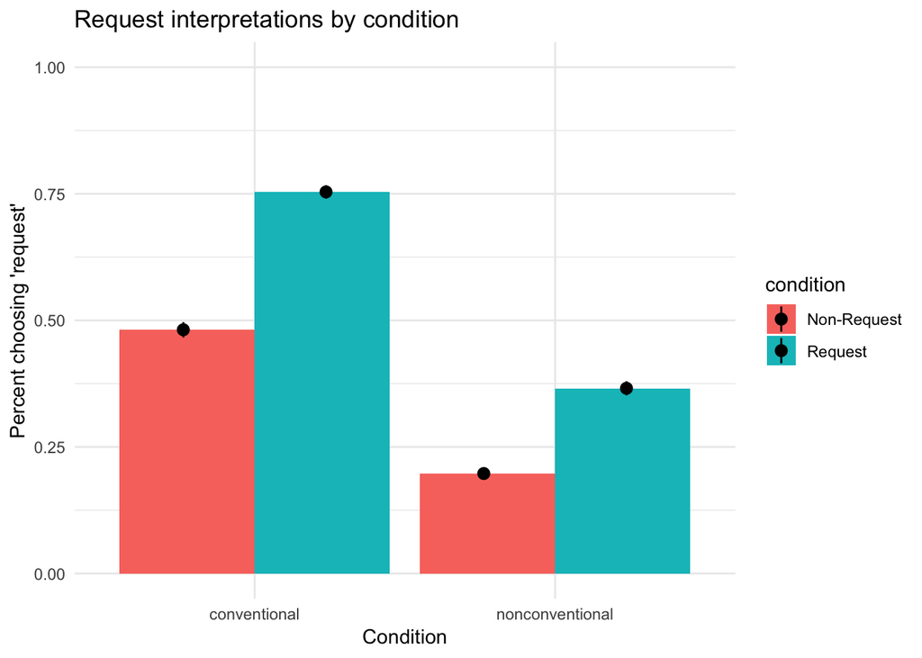

```r
coded %>%
  ggplot(aes(x = form, y = numeric_response, fill = condition)) +
  geom_bar(stat="summary", position="dodge", fun.y="mean") +
  stat_summary (fun.y = function(x){mean(x)},
                fun.ymin = function(x){mean(x) - 1*sd(x)/sqrt(length(x))},
                fun.ymax = function(x){mean(x) + 1*sd(x)/sqrt(length(x))},
                geom= 'pointrange',
                position=position_dodge(width=0.95)) +
  theme_minimal() +
  ggtitle("Request interpretations by condition") +
  xlab("Condition") +
  ylab("Percent choosing 'request'") +
  scale_y_continuous(limits = c(0, 1))
```

## Analysis

Both `form` and `condition` explain significant sources of variance in participants’ responses.

```r
m1_full = glmer(data=coded, response ~ condition + form +
                       (1 + condition | stimNum) +
             (1 + condition + form | subject),
           control=glmerControl(optimizer="bobyqa"),
         family=binomial())
```

```
## boundary (singular) fit: see ?isSingular
```

```r
m1_no_form = glmer(data=coded, response ~ condition + (1 + condition | stimNum) +
             (1 + condition + form | subject),
           control=glmerControl(optimizer="bobyqa"),
         family=binomial())
```

```
## boundary (singular) fit: see ?isSingular
```

```r
m1_no_condition = glmer(data=coded, response ~ form + (1 + condition | stimNum) +
             (1 + condition + form | subject),
           control=glmerControl(optimizer="bobyqa"),
         family=binomial())


anova(m1_full, m1_no_form)
```

```
## Data: coded
## Models:
## m1_no_form: response ~ condition + (1 + condition | stimNum) + (1 + condition +
## m1_no_form:     form | subject)
## m1_full: response ~ condition + form + (1 + condition | stimNum) + (1 +
## m1_full:     condition + form | subject)
##            Df    AIC    BIC  logLik deviance  Chisq Chi Df Pr(>Chisq)
## m1_no_form 11 4837.1 4907.8 -2407.5   4815.1
## m1_full    12 4820.8 4897.9 -2398.4   4796.8 18.309      1  1.878e-05 ***
## ---
## Signif. codes:  0 '***' 0.001 '**' 0.01 '*' 0.05 '.' 0.1 ' ' 1
```

```r
anova(m1_full, m1_no_condition)
```

```
## Data: coded
## Models:
## m1_no_condition: response ~ form + (1 + condition | stimNum) + (1 + condition +
## m1_no_condition:     form | subject)
## m1_full: response ~ condition + form + (1 + condition | stimNum) + (1 +
## m1_full:     condition + form | subject)
##                 Df    AIC    BIC  logLik deviance  Chisq Chi Df Pr(>Chisq)
## m1_no_condition 11 4856.8 4927.4 -2417.4   4834.8
## m1_full         12 4820.8 4897.9 -2398.4   4796.8 37.997      1  7.087e-10
##
## m1_no_condition
## m1_full         ***
## ---
## Signif. codes:  0 '***' 0.001 '**' 0.01 '*' 0.05 '.' 0.1 ' ' 1
```

```r
summary(m1_full)
```

```
## Generalized linear mixed model fit by maximum likelihood (Laplace
##   Approximation) [glmerMod]
##  Family: binomial  ( logit )
## Formula: response ~ condition + form + (1 + condition | stimNum) + (1 +
##     condition + form | subject)
##    Data: coded
## Control: glmerControl(optimizer = "bobyqa")
##
##      AIC      BIC   logLik deviance df.resid
##   4820.8   4897.9  -2398.4   4796.8     4548
##
## Scaled residuals:
##     Min      1Q  Median      3Q     Max
## -3.9634 -0.6464 -0.1360  0.6740  4.4413
##
## Random effects:
##  Groups  Name                Variance Std.Dev. Corr
##  subject (Intercept)         0.415547 0.64463
##          conditionRequest    0.439594 0.66302  -0.52
##          formnonconventional 2.490362 1.57809   0.41 -0.40
##  stimNum (Intercept)         0.178815 0.42287
##          conditionRequest    0.009477 0.09735  1.00
## Number of obs: 4560, groups:  subject, 76; stimNum, 12
##
## Fixed effects:
##                     Estimate Std. Error z value Pr(>|z|)
## (Intercept)         -0.07443    0.21372  -0.348    0.728
## conditionRequest     1.30034    0.12236  10.627  < 2e-16 ***
## formnonconventional -2.15331    0.42425  -5.076 3.86e-07 ***
## ---
## Signif. codes:  0 '***' 0.001 '**' 0.01 '*' 0.05 '.' 0.1 ' ' 1
##
## Correlation of Fixed Effects:
##             (Intr) cndtnR
## conditnRqst -0.082
## frmnncnvntn -0.488 -0.200
## convergence code: 0
## boundary (singular) fit: see ?isSingular
```

# How does accuracy interact with other factors?

# Already heard utterance

```r
m1 = glmer(data=coded, correct ~ already_heard_by_speaker +
             (1 + already_heard_by_speaker | stimNum) +
             (1 | subject),
           control=glmerControl(optimizer="bobyqa"),
         family=binomial())

m1.reduced =glmer(data=coded, correct ~ (1 + already_heard_by_speaker | stimNum) +
                    (1 | subject),
                  control=glmerControl(optimizer="bobyqa"),
                    family=binomial())
```

```
## boundary (singular) fit: see ?isSingular
```

```r
anova(m1, m1.reduced)
```

```
## Data: coded
## Models:
## m1.reduced: correct ~ (1 + already_heard_by_speaker | stimNum) + (1 | subject)
## m1: correct ~ already_heard_by_speaker + (1 + already_heard_by_speaker |
## m1:     stimNum) + (1 | subject)
##            Df    AIC    BIC  logLik deviance  Chisq Chi Df Pr(>Chisq)
## m1.reduced  5 6088.2 6120.4 -3039.1   6078.2
## m1          6 6090.1 6128.6 -3039.0   6078.1 0.1864      1      0.666
```

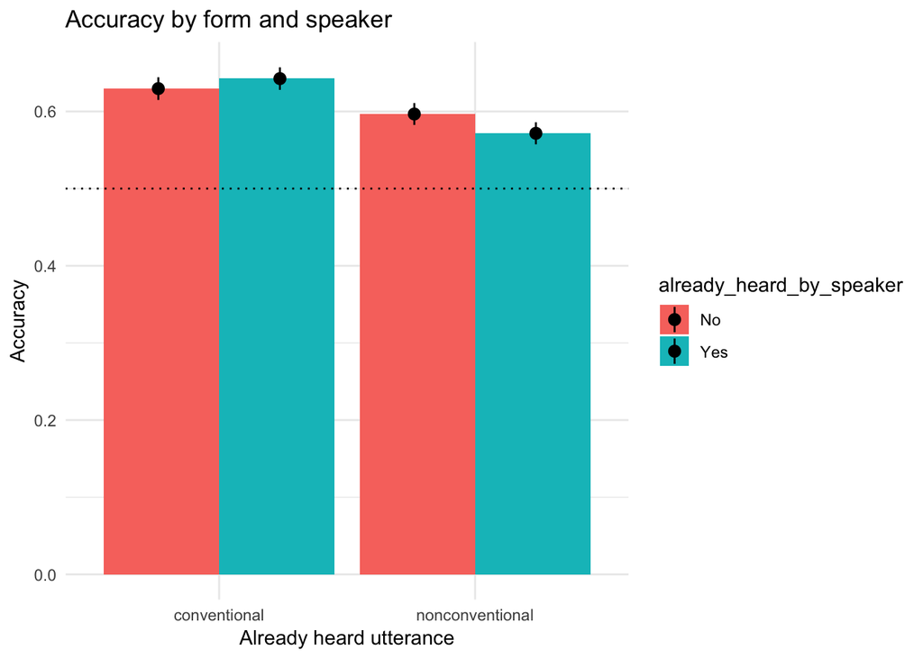

```r
coded %>%
  ggplot(aes(x = form, y = correct, fill = already_heard_by_speaker)) +
  geom_bar(stat="summary", position="dodge", fun.y="mean") +
  stat_summary (fun.y = function(x){mean(x)},
                fun.ymin = function(x){mean(x) - 1*sd(x)/sqrt(length(x))},
                fun.ymax = function(x){mean(x) + 1*sd(x)/sqrt(length(x))},
                geom= 'pointrange',
                position=position_dodge(width=0.95)) +
  theme_minimal() +
  labs(x = "Already heard utterance",
       y = "Accuracy",
       title = "Accuracy by form and speaker") +
  geom_hline(yintercept=.5, colour="black", linetype="dotted")
```

## Visualization

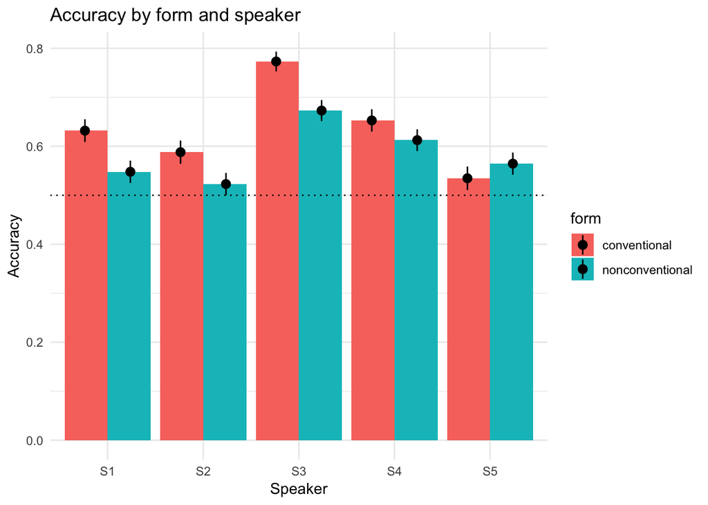

```r
coded %>%
  ggplot(aes(x = speaker, y = correct, fill = form)) +
  geom_bar(stat="summary", position="dodge", fun.y="mean") +
  stat_summary (fun.y = function(x){mean(x)},
                fun.ymin = function(x){mean(x) - 1*sd(x)/sqrt(length(x))},
                fun.ymax = function(x){mean(x) + 1*sd(x)/sqrt(length(x))},
                geom= 'pointrange',
                position=position_dodge(width=0.95)) +
  theme_minimal() +
  labs(x = "Speaker",
       y = "Accuracy",
       title = "Accuracy by form and speaker") +
  geom_hline(yintercept=.5, colour="black", linetype="dotted")
```

## Analysis

### Building the models

```r
m1 = glmer(data=coded, correct ~ form*speaker + already_heard_by_speaker + (1 | stimNum) +
             (1 + form | subject),
           control=glmerControl(optimizer="bobyqa"),
         family=binomial())
```

```
## boundary (singular) fit: see ?isSingular
```

```r
m1.reduced =glmer(data=coded, correct ~ form + speaker + already_heard_by_speaker + (1 | stimNum) +
                    (1 + form | subject),
                  control=glmerControl(optimizer="bobyqa"),
                    family=binomial())
```

```
## boundary (singular) fit: see ?isSingular
```

```r
m1.reduced.form = glmer(data=coded, correct ~ form + already_heard_by_speaker + (1 | stimNum) +
                    (1 + form | subject),
                  control=glmerControl(optimizer="bobyqa"),
                    family=binomial())
```

```
## boundary (singular) fit: see ?isSingular
```

```r
m1.reduced.speaker = glmer(data=coded, correct ~ speaker + already_heard_by_speaker +(1 | stimNum) +
                    (1 + form | subject),
                  control=glmerControl(optimizer="bobyqa"),
                    family=binomial())
```

```
## boundary (singular) fit: see ?isSingular
```

```r
m1.null = glmer(data=coded, correct ~ already_heard_by_speaker +(1 | stimNum) +
                    (1 + form | subject),
                  control=glmerControl(optimizer="bobyqa"),
                    family=binomial())
```

```
## boundary (singular) fit: see ?isSingular
```

### Model comparisons

```r
anova(m1, m1.reduced)
```

```
## Data: coded
## Models:
## m1.reduced: correct ~ form + speaker + already_heard_by_speaker + (1 | stimNum) +
## m1.reduced:     (1 + form | subject)
## m1: correct ~ form * speaker + already_heard_by_speaker + (1 | stimNum) +
## m1:     (1 + form | subject)
##            Df    AIC    BIC  logLik deviance  Chisq Chi Df Pr(>Chisq)
## m1.reduced 11 6014.3 6085.0 -2996.2   5992.3
## m1         15 6010.8 6107.2 -2990.4   5980.8 11.516      4    0.02134 *
## ---
## Signif. codes:  0 '***' 0.001 '**' 0.01 '*' 0.05 '.' 0.1 ' ' 1
```

```r
anova(m1.reduced, m1.reduced.form)
```

```
## Data: coded
## Models:
## m1.reduced.form: correct ~ form + already_heard_by_speaker + (1 | stimNum) + (1 +
## m1.reduced.form:     form | subject)
## m1.reduced: correct ~ form + speaker + already_heard_by_speaker + (1 | stimNum) +
## m1.reduced:     (1 + form | subject)
##                 Df    AIC    BIC  logLik deviance  Chisq Chi Df Pr(>Chisq)
## m1.reduced.form  7 6085.6 6130.5 -3035.8   6071.6
## m1.reduced      11 6014.3 6085.0 -2996.2   5992.3 79.264      4  2.494e-16
##
## m1.reduced.form
## m1.reduced      ***
## ---
## Signif. codes:  0 '***' 0.001 '**' 0.01 '*' 0.05 '.' 0.1 ' ' 1
```

```r
anova(m1.reduced, m1.reduced.speaker)
```

```
## Data: coded
## Models:
## m1.reduced.speaker: correct ~ speaker + already_heard_by_speaker + (1 | stimNum) +
## m1.reduced.speaker:     (1 + form | subject)
## m1.reduced: correct ~ form + speaker + already_heard_by_speaker + (1 | stimNum) +
## m1.reduced:     (1 + form | subject)
##                    Df    AIC    BIC  logLik deviance  Chisq Chi Df
## m1.reduced.speaker 10 6019.0 6083.2 -2999.5   5999.0
## m1.reduced         11 6014.3 6085.0 -2996.2   5992.3 6.6439      1
##                    Pr(>Chisq)
## m1.reduced.speaker
## m1.reduced           0.009949 **
## ---
## Signif. codes:  0 '***' 0.001 '**' 0.01 '*' 0.05 '.' 0.1 ' ' 1
```

```r
anova(m1.reduced.form, m1.null)
```

```
## Data: coded
## Models:
## m1.null: correct ~ already_heard_by_speaker + (1 | stimNum) + (1 + form |
## m1.null:     subject)
## m1.reduced.form: correct ~ form + already_heard_by_speaker + (1 | stimNum) + (1 +
## m1.reduced.form:     form | subject)
##                 Df    AIC    BIC  logLik deviance  Chisq Chi Df Pr(>Chisq)
## m1.null          6 6090.2 6128.8 -3039.1   6078.2
## m1.reduced.form  7 6085.6 6130.5 -3035.8   6071.6 6.6488      1   0.009922
##
## m1.null
## m1.reduced.form **
## ---
## Signif. codes:  0 '***' 0.001 '**' 0.01 '*' 0.05 '.' 0.1 ' ' 1
```

```r
anova(m1.reduced.speaker, m1.null)
```

```
## Data: coded
## Models:
## m1.null: correct ~ already_heard_by_speaker + (1 | stimNum) + (1 + form |
## m1.null:     subject)
## m1.reduced.speaker: correct ~ speaker + already_heard_by_speaker + (1 | stimNum) +
## m1.reduced.speaker:     (1 + form | subject)
##                    Df    AIC    BIC  logLik deviance  Chisq Chi Df
## m1.null             6 6090.2 6128.8 -3039.1   6078.2
## m1.reduced.speaker 10 6019.0 6083.2 -2999.5   5999.0 79.269      4
##                    Pr(>Chisq)
## m1.null
## m1.reduced.speaker  2.488e-16 ***
## ---
## Signif. codes:  0 '***' 0.001 '**' 0.01 '*' 0.05 '.' 0.1 ' ' 1
```

## Analysis

```r
m1.order =glmer(data=coded, correct ~ Order + (1 | stimNum) +
                    (1 | subject),
                  control=glmerControl(optimizer="bobyqa"),
                  family=binomial())
```

```
## boundary (singular) fit: see ?isSingular
```

```r
m1.null =glmer(data=coded, correct ~ (1 | stimNum) +
                    (1 | subject),
                  control=glmerControl(optimizer="bobyqa"),
                  family=binomial())
```

```
## boundary (singular) fit: see ?isSingular
```

```r
anova(m1.order,m1.null)
```

```
## Data: coded
## Models:
## m1.null: correct ~ (1 | stimNum) + (1 | subject)
## m1.order: correct ~ Order + (1 | stimNum) + (1 | subject)
##          Df    AIC    BIC  logLik deviance Chisq Chi Df Pr(>Chisq)
## m1.null   3 6084.6 6103.8 -3039.3   6078.6
## m1.order  4 6070.7 6096.4 -3031.3   6062.7 15.91      1  6.642e-05 ***
## ---
## Signif. codes:  0 '***' 0.001 '**' 0.01 '*' 0.05 '.' 0.1 ' ' 1
```

## Order by block

It might also be the case that accuracy improves for each block.

```r
coded$order_by_block = coded$Order %% 12
table(coded$order_by_block)
```

```
##
##   0   1   2   3   4   5   6   7   8   9  10  11
## 380 380 380 380 380 380 380 380 380 380 380 380
```

```r
# Recode the 0s from this procedure
coded$order_by_block = ifelse(coded$order_by_block == 0, 12, coded$order_by_block)

m1.order_with_speaker_interaction =glmer(data=coded, correct ~ order_by_block * speaker + (1 | stimNum) +
                    (1 | subject),
                  control=glmerControl(optimizer="bobyqa"),
                  family=binomial())
```

```
## boundary (singular) fit: see ?isSingular
```

```r
m1.order_plus_speaker =glmer(data=coded, correct ~ order_by_block + speaker + (1 | stimNum) +
                    (1 | subject),
                  control=glmerControl(optimizer="bobyqa"),
                  family=binomial())
```

```
## boundary (singular) fit: see ?isSingular
```

```r
m1.only_speaker =glmer(data=coded, correct ~ speaker + (1 | stimNum) +
                    (1 | subject),
                  control=glmerControl(optimizer="bobyqa"),
                  family=binomial())
```

```
## boundary (singular) fit: see ?isSingular
```

```r
m1.order_by_block =glmer(data=coded, correct ~ order_by_block + (1 | stimNum) +
                    (1 | subject),
                  control=glmerControl(optimizer="bobyqa"),
                  family=binomial())
```

```
## boundary (singular) fit: see ?isSingular
```

```r
m1.null =glmer(data=coded, correct ~ (1 | stimNum) +
                    (1 | subject),
                  control=glmerControl(optimizer="bobyqa"),
                  family=binomial())
```

```
## boundary (singular) fit: see ?isSingular
```

```r
anova(m1.order_with_speaker_interaction, m1.order_plus_speaker)
```

```
## Data: coded
## Models:
## m1.order_plus_speaker: correct ~ order_by_block + speaker + (1 | stimNum) + (1 | subject)
## m1.order_with_speaker_interaction: correct ~ order_by_block * speaker + (1 | stimNum) + (1 | subject)
##                                   Df    AIC    BIC  logLik deviance  Chisq
## m1.order_plus_speaker              8 6014.9 6066.3 -2999.4   5998.9
## m1.order_with_speaker_interaction 12 6019.9 6097.0 -2997.9   5995.9 2.9605
##                                   Chi Df Pr(>Chisq)
## m1.order_plus_speaker
## m1.order_with_speaker_interaction      4     0.5645
```

```r
anova(m1.order_plus_speaker, m1.only_speaker)
```

```
## Data: coded
## Models:
## m1.only_speaker: correct ~ speaker + (1 | stimNum) + (1 | subject)
## m1.order_plus_speaker: correct ~ order_by_block + speaker + (1 | stimNum) + (1 | subject)
##                       Df    AIC    BIC  logLik deviance  Chisq Chi Df
## m1.only_speaker        7 6013.3 6058.3 -2999.7   5999.3
## m1.order_plus_speaker  8 6014.9 6066.3 -2999.4   5998.9 0.4266      1
##                       Pr(>Chisq)
## m1.only_speaker
## m1.order_plus_speaker     0.5137
```

```r
anova(m1.order_by_block, m1.null)
```

```
## Data: coded
## Models:
## m1.null: correct ~ (1 | stimNum) + (1 | subject)
## m1.order_by_block: correct ~ order_by_block + (1 | stimNum) + (1 | subject)
##                   Df    AIC    BIC  logLik deviance  Chisq Chi Df
## m1.null            3 6084.6 6103.8 -3039.3   6078.6
## m1.order_by_block  4 6086.1 6111.8 -3039.1   6078.1 0.4192      1
##                   Pr(>Chisq)
## m1.null
## m1.order_by_block     0.5174
```

# Analysis of acoustic features

Now we load the raw audio files and try to predict subject’s responses from acoustic features. We follow the z-scaling procedure reported in Trott & Bergen (2019, CogSci submission).

## Dataset

```r
df_audio = read_csv("../../data/audio_features/audio_features.csv")
df_audio$label = factor(df_audio$label)

df_audio$label = fct_recode(df_audio$label,
                            "Request" = "IR",
                            "Non-Request" = "Literal")


df_audio$speaker = factor(df_audio$speaker)

df_audio = df_audio %>%
  group_by(speaker) %>%
  mutate(mean_f0_z_score = scale(mean_f0),
         duration_f0_z_score = scale(duration_f0),
         range_f0_z_score = scale(range_f0),
         sd_f0_z_score = scale(sd_f0),
         slope_f0_z_score = scale(slope_f0),
         mean_intensity_z_score = scale(mean_intensity),
         sd_intensity_z_score = scale(sd_intensity)
         )
```

## Merge datasets

```r
df_audio$item = factor(paste(df_audio$speaker, df_audio$stimNum, df_audio$label, sep="_"))
coded$item = factor(paste(coded$speaker, coded$stimNum, coded$condition, sep = "_"))

new_df = data.frame(item=df_audio$item,
                    mean_f0_z_score=df_audio$mean_f0_z_score,
                    duration_f0_z_score=df_audio$duration_f0_z_score,
                    range_f0_z_score=df_audio$range_f0_z_score,
                    sd_f0_z_score=df_audio$sd_f0_z_score,
                    slope_f0_z_score=df_audio$slope_f0_z_score,
                    mean_intensity_z_score=df_audio$mean_intensity_z_score,
                    sd_intensity_z_score=df_audio$sd_intensity_z_score)


merged = merge(coded, new_df, by="item")
nrow(coded)
```

```
## [1] 4560
```

```r
nrow(merged)
```

```
## [1] 4560
```

```r
merged$response = fct_recode(merged$response,
                             "Request" = "request",
                             "Non-Request" = "literal")
merged$response = factor(merged$response, levels=c("Request", "Non-Request"))
merged$form = factor(merged$form, levels=c("nonconventional", "conventional"))
```

## Analysis

Now we ask whether adding acoustic features to the model predicts participants’ **responses**, above and beyond the variance explained by *form* and *speaker* (and their interaction).

To do this, we compare each model in turn, successively dropping out different acoustic features.

Random effects include random intercepts for subjects and items. Including a random slope for the effect of form for items (as in the models above) prevents the models from converging. (That said, analysis of these models suggests very similar results.)

### Do the features predict participants’ predicted label?

```r
model_response_full = glmer(data = merged,
                      response ~ slope_f0_z_score * form +
                        mean_f0_z_score * form +
                       duration_f0_z_score * form +
                       range_f0_z_score * form +
                       sd_f0_z_score * form +
                       mean_intensity_z_score * form +
                       sd_intensity_z_score * form +
                        form * speaker +
                        already_heard_by_speaker +
                        (1 | subject) + (1 | stimNum),
                       control=glmerControl(optimizer="bobyqa"),
                       family = binomial())


summary(model_response_full)
```

```
## Generalized linear mixed model fit by maximum likelihood (Laplace
##   Approximation) [glmerMod]
##  Family: binomial  ( logit )
## Formula: response ~ slope_f0_z_score * form + mean_f0_z_score * form +
##     duration_f0_z_score * form + range_f0_z_score * form + sd_f0_z_score *
##     form + mean_intensity_z_score * form + sd_intensity_z_score *
##     form + form * speaker + already_heard_by_speaker + (1 | subject) +
##     (1 | stimNum)
##    Data: merged
## Control: glmerControl(optimizer = "bobyqa")
##
##      AIC      BIC   logLik deviance df.resid
##   4679.1   4852.6  -2312.6   4625.1     4533
##
## Scaled residuals:
##     Min      1Q  Median      3Q     Max
## -5.6187 -0.6315  0.1444  0.5960  5.9876
##
## Random effects:
##  Groups  Name        Variance Std.Dev.
##  subject (Intercept) 1.6008   1.2652
##  stimNum (Intercept) 0.2952   0.5434
## Number of obs: 4560, groups:  subject, 76; stimNum, 12
##
## Fixed effects:
##                                         Estimate Std. Error z value
## (Intercept)                              0.66270    0.32590   2.033
## slope_f0_z_score                        -0.15994    0.09763  -1.638
## formconventional                        -1.19128    0.45887  -2.596
## mean_f0_z_score                         -0.53468    0.14367  -3.722
## duration_f0_z_score                     -0.55091    0.07950  -6.930
## range_f0_z_score                         0.14079    0.17143   0.821
## sd_f0_z_score                           -0.02914    0.21036  -0.139
## mean_intensity_z_score                  -0.23555    0.06638  -3.548
## sd_intensity_z_score                     0.08574    0.07262   1.181
## speakerS2                                1.41786    0.19447   7.291
## speakerS3                               -0.27316    0.17163  -1.592
## speakerS4                                0.93773    0.18291   5.127
## speakerS5                                0.81352    0.17243   4.718
## already_heard_by_speakerYes              0.05524    0.07401   0.746
```

[output cut: 24 more lines]

```
## speakerS5                               2.38e-06 ***
## already_heard_by_speakerYes             0.455448
## slope_f0_z_score:formconventional       2.86e-08 ***
## formconventional:mean_f0_z_score        0.000231 ***
## formconventional:duration_f0_z_score     < 2e-16 ***
## formconventional:range_f0_z_score       0.228272
## formconventional:sd_f0_z_score          0.702082
## formconventional:mean_intensity_z_score 0.031179 *
## formconventional:sd_intensity_z_score   0.269346
## formconventional:speakerS2              7.63e-14 ***
## formconventional:speakerS3              0.017544 *
## formconventional:speakerS4              7.62e-08 ***
## formconventional:speakerS5              2.31e-12 ***
## ---
## Signif. codes:  0 '***' 0.001 '**' 0.01 '*' 0.05 '.' 0.1 ' ' 1
```

```
##
## Correlation matrix not shown by default, as p = 25 > 12.
## Use print(x, correlation=TRUE)  or
##     vcov(x)        if you need it
```

#### F0 slope

```r
model_response_no_slope_interaction = glmer(data = merged,
                      response ~ slope_f0_z_score +
                      mean_f0_z_score * form +
                      duration_f0_z_score * form +
                       range_f0_z_score * form +
                       sd_f0_z_score * form +
                       mean_intensity_z_score * form +
                       sd_intensity_z_score * form +
                        form * speaker +
                        already_heard_by_speaker +
                        (1 | subject) + (1 | stimNum),
                       control=glmerControl(optimizer="bobyqa"),
                       family = binomial())

model_response_no_slope = glmer(data = merged,
                      response ~ mean_f0_z_score * form +
                       duration_f0_z_score * form +
                       range_f0_z_score * form +
                       sd_f0_z_score * form +
                       mean_intensity_z_score * form +
                       sd_intensity_z_score * form +
                        form * speaker +
                        already_heard_by_speaker +
                        (1 | subject) + (1 | stimNum),
                       control=glmerControl(optimizer="bobyqa"),
                       family = binomial())
```

```r
anova(model_response_full, model_response_no_slope_interaction)
```

```
## Data: merged
## Models:
## model_response_no_slope_interaction: response ~ slope_f0_z_score + mean_f0_z_score * form + duration_f0_z_score *
## model_response_no_slope_interaction:     form + range_f0_z_score * form + sd_f0_z_score * form + mean_intensity_z_score *
## model_response_no_slope_interaction:     form + sd_intensity_z_score * form + form * speaker + already_heard_by_speaker +
## model_response_no_slope_interaction:     (1 | subject) + (1 | stimNum)
## model_response_full: response ~ slope_f0_z_score * form + mean_f0_z_score * form +
## model_response_full:     duration_f0_z_score * form + range_f0_z_score * form + sd_f0_z_score *
## model_response_full:     form + mean_intensity_z_score * form + sd_intensity_z_score *
## model_response_full:     form + form * speaker + already_heard_by_speaker + (1 | subject) +
## model_response_full:     (1 | stimNum)
##                                     Df    AIC    BIC  logLik deviance
## model_response_no_slope_interaction 26 4708.8 4875.8 -2328.4   4656.8
## model_response_full                 27 4679.1 4852.6 -2312.6   4625.1
##                                      Chisq Chi Df Pr(>Chisq)
## model_response_no_slope_interaction
## model_response_full                 31.633      1  1.862e-08 ***
## ---
## Signif. codes:  0 '***' 0.001 '**' 0.01 '*' 0.05 '.' 0.1 ' ' 1
```

```r
anova(model_response_no_slope_interaction, model_response_no_slope)
```

```
## Data: merged
## Models:
## model_response_no_slope: response ~ mean_f0_z_score * form + duration_f0_z_score * form +
## model_response_no_slope:     range_f0_z_score * form + sd_f0_z_score * form + mean_intensity_z_score *
## model_response_no_slope:     form + sd_intensity_z_score * form + form * speaker + already_heard_by_speaker +
## model_response_no_slope:     (1 | subject) + (1 | stimNum)
## model_response_no_slope_interaction: response ~ slope_f0_z_score + mean_f0_z_score * form + duration_f0_z_score *
## model_response_no_slope_interaction:     form + range_f0_z_score * form + sd_f0_z_score * form + mean_intensity_z_score *
## model_response_no_slope_interaction:     form + sd_intensity_z_score * form + form * speaker + already_heard_by_speaker +
## model_response_no_slope_interaction:     (1 | subject) + (1 | stimNum)
##                                     Df    AIC    BIC  logLik deviance
## model_response_no_slope             25 4733.7 4894.4 -2341.9   4683.7
## model_response_no_slope_interaction 26 4708.8 4875.8 -2328.4   4656.8
##                                      Chisq Chi Df Pr(>Chisq)
## model_response_no_slope
## model_response_no_slope_interaction 26.956      1  2.081e-07 ***
## ---
## Signif. codes:  0 '***' 0.001 '**' 0.01 '*' 0.05 '.' 0.1 ' ' 1
```

#### Mean F0

```r
model_response_no_mean_f0_interaction = glmer(data = merged,
                      response ~ slope_f0_z_score * form +
                        mean_f0_z_score +
                       duration_f0_z_score * form +
                       range_f0_z_score * form +
                       sd_f0_z_score * form +
                       mean_intensity_z_score * form +
                       sd_intensity_z_score * form +
                        form * speaker +
                        already_heard_by_speaker +
                        (1 | subject) + (1 | stimNum),
                       control=glmerControl(optimizer="bobyqa"),
                       family = binomial())

model_response_no_mean_f0 = glmer(data = merged,
                      response ~ slope_f0_z_score * form +
                       duration_f0_z_score * form +
                       range_f0_z_score * form +
                       sd_f0_z_score * form +
                       mean_intensity_z_score * form +
                       sd_intensity_z_score * form +
                        form * speaker +
                        already_heard_by_speaker +
                        (1 | subject) + (1 | stimNum),
                       control=glmerControl(optimizer="bobyqa"),
                       family = binomial())
```

```r
anova(model_response_full, model_response_no_mean_f0_interaction)
```

```
## Data: merged
## Models:
## model_response_no_mean_f0_interaction: response ~ slope_f0_z_score * form + mean_f0_z_score + duration_f0_z_score *
## model_response_no_mean_f0_interaction:     form + range_f0_z_score * form + sd_f0_z_score * form + mean_intensity_z_score *
## model_response_no_mean_f0_interaction:     form + sd_intensity_z_score * form + form * speaker + already_heard_by_speaker +
## model_response_no_mean_f0_interaction:     (1 | subject) + (1 | stimNum)
## model_response_full: response ~ slope_f0_z_score * form + mean_f0_z_score * form +
## model_response_full:     duration_f0_z_score * form + range_f0_z_score * form + sd_f0_z_score *
## model_response_full:     form + mean_intensity_z_score * form + sd_intensity_z_score *
## model_response_full:     form + form * speaker + already_heard_by_speaker + (1 | subject) +
## model_response_full:     (1 | stimNum)
##                                       Df    AIC    BIC  logLik deviance
## model_response_no_mean_f0_interaction 26 4690.6 4857.6 -2319.3   4638.6
## model_response_full                   27 4679.1 4852.6 -2312.6   4625.1
##                                        Chisq Chi Df Pr(>Chisq)
## model_response_no_mean_f0_interaction
## model_response_full                   13.457      1   0.000244 ***
## ---
## Signif. codes:  0 '***' 0.001 '**' 0.01 '*' 0.05 '.' 0.1 ' ' 1
```

```r
anova(model_response_no_mean_f0_interaction, model_response_no_mean_f0)
```

```
## Data: merged
## Models:
## model_response_no_mean_f0: response ~ slope_f0_z_score * form + duration_f0_z_score * form +
## model_response_no_mean_f0:     range_f0_z_score * form + sd_f0_z_score * form + mean_intensity_z_score *
## model_response_no_mean_f0:     form + sd_intensity_z_score * form + form * speaker + already_heard_by_speaker +
## model_response_no_mean_f0:     (1 | subject) + (1 | stimNum)
## model_response_no_mean_f0_interaction: response ~ slope_f0_z_score * form + mean_f0_z_score + duration_f0_z_score *
## model_response_no_mean_f0_interaction:     form + range_f0_z_score * form + sd_f0_z_score * form + mean_intensity_z_score *
## model_response_no_mean_f0_interaction:     form + sd_intensity_z_score * form + form * speaker + already_heard_by_speaker +
## model_response_no_mean_f0_interaction:     (1 | subject) + (1 | stimNum)
##                                       Df    AIC    BIC  logLik deviance
## model_response_no_mean_f0             25 4689.5 4850.2 -2319.8   4639.5
## model_response_no_mean_f0_interaction 26 4690.6 4857.6 -2319.3   4638.6
##                                        Chisq Chi Df Pr(>Chisq)
## model_response_no_mean_f0
## model_response_no_mean_f0_interaction 0.9464      1     0.3306
```

#### F0 duration (number of voiced frames)

```r
model_response_no_f0_dur_interaction = glmer(data = merged,
                      response ~ slope_f0_z_score * form +
                        mean_f0_z_score * form +
                       duration_f0_z_score +
                       range_f0_z_score * form +
                       sd_f0_z_score * form +
                       mean_intensity_z_score * form +
                       sd_intensity_z_score * form +
                        form * speaker +
                        already_heard_by_speaker +
                        (1 | subject) + (1 | stimNum),
                       control=glmerControl(optimizer="bobyqa"),
                       family = binomial())

model_response_no_f0_dur = glmer(data = merged,
                      response ~ slope_f0_z_score * form +
                        mean_f0_z_score * form +
                       range_f0_z_score * form +
                       sd_f0_z_score * form +
                       mean_intensity_z_score * form +
                       sd_intensity_z_score * form +
                        already_heard_by_speaker +
                        form * speaker +
                        (1 | subject) + (1 | stimNum),
                       control=glmerControl(optimizer="bobyqa"),
                       family = binomial())
```

```r
anova(model_response_full, model_response_no_f0_dur_interaction)
```

```
## Data: merged
## Models:
## model_response_no_f0_dur_interaction: response ~ slope_f0_z_score * form + mean_f0_z_score * form +
## model_response_no_f0_dur_interaction:     duration_f0_z_score + range_f0_z_score * form + sd_f0_z_score *
## model_response_no_f0_dur_interaction:     form + mean_intensity_z_score * form + sd_intensity_z_score *
## model_response_no_f0_dur_interaction:     form + form * speaker + already_heard_by_speaker + (1 | subject) +
## model_response_no_f0_dur_interaction:     (1 | stimNum)
## model_response_full: response ~ slope_f0_z_score * form + mean_f0_z_score * form +
## model_response_full:     duration_f0_z_score * form + range_f0_z_score * form + sd_f0_z_score *
## model_response_full:     form + mean_intensity_z_score * form + sd_intensity_z_score *
## model_response_full:     form + form * speaker + already_heard_by_speaker + (1 | subject) +
## model_response_full:     (1 | stimNum)
##                                      Df    AIC    BIC  logLik deviance
## model_response_no_f0_dur_interaction 26 4819.3 4986.3 -2383.6   4767.3
## model_response_full                  27 4679.1 4852.6 -2312.6   4625.1
##                                       Chisq Chi Df Pr(>Chisq)
## model_response_no_f0_dur_interaction
## model_response_full                  142.15      1  < 2.2e-16 ***
## ---
## Signif. codes:  0 '***' 0.001 '**' 0.01 '*' 0.05 '.' 0.1 ' ' 1
```

```r
anova(model_response_no_f0_dur_interaction, model_response_no_f0_dur)
```

```
## Data: merged
## Models:
## model_response_no_f0_dur: response ~ slope_f0_z_score * form + mean_f0_z_score * form +
## model_response_no_f0_dur:     range_f0_z_score * form + sd_f0_z_score * form + mean_intensity_z_score *
## model_response_no_f0_dur:     form + sd_intensity_z_score * form + already_heard_by_speaker +
## model_response_no_f0_dur:     form * speaker + (1 | subject) + (1 | stimNum)
## model_response_no_f0_dur_interaction: response ~ slope_f0_z_score * form + mean_f0_z_score * form +
## model_response_no_f0_dur_interaction:     duration_f0_z_score + range_f0_z_score * form + sd_f0_z_score *
## model_response_no_f0_dur_interaction:     form + mean_intensity_z_score * form + sd_intensity_z_score *
## model_response_no_f0_dur_interaction:     form + form * speaker + already_heard_by_speaker + (1 | subject) +
## model_response_no_f0_dur_interaction:     (1 | stimNum)
##                                      Df    AIC    BIC  logLik deviance
## model_response_no_f0_dur             25 4823.7 4984.4 -2386.9   4773.7
## model_response_no_f0_dur_interaction 26 4819.3 4986.3 -2383.6   4767.3
##                                       Chisq Chi Df Pr(>Chisq)
## model_response_no_f0_dur
## model_response_no_f0_dur_interaction 6.4466      1    0.01112 *
## ---
## Signif. codes:  0 '***' 0.001 '**' 0.01 '*' 0.05 '.' 0.1 ' ' 1
```

#### F0 range

```r
model_response_no_f0_range_interaction = glmer(data = merged,
                      response ~ slope_f0_z_score * form +
                        mean_f0_z_score * form +
                       duration_f0_z_score * form +
                       range_f0_z_score +
                       sd_f0_z_score * form +
                       mean_intensity_z_score * form +
                       sd_intensity_z_score * form +
                        form * speaker +
                        already_heard_by_speaker +
                        (1 | subject) + (1 | stimNum),
                       control=glmerControl(optimizer="bobyqa"),
                       family = binomial())

model_response_no_f0_range = glmer(data = merged,
                      response ~ slope_f0_z_score * form +
                        mean_f0_z_score * form +
                       duration_f0_z_score * form +
                       sd_f0_z_score * form +
                       mean_intensity_z_score * form +
                       sd_intensity_z_score * form +
                        form * speaker +
                        already_heard_by_speaker +
                        (1 | subject) + (1 | stimNum),
                       control=glmerControl(optimizer="bobyqa"),
                       family = binomial())
```

```r
anova(model_response_full, model_response_no_f0_range_interaction)
```

```
## Data: merged
## Models:
## model_response_no_f0_range_interaction: response ~ slope_f0_z_score * form + mean_f0_z_score * form +
## model_response_no_f0_range_interaction:     duration_f0_z_score * form + range_f0_z_score + sd_f0_z_score *
## model_response_no_f0_range_interaction:     form + mean_intensity_z_score * form + sd_intensity_z_score *
## model_response_no_f0_range_interaction:     form + form * speaker + already_heard_by_speaker + (1 | subject) +
## model_response_no_f0_range_interaction:     (1 | stimNum)
## model_response_full: response ~ slope_f0_z_score * form + mean_f0_z_score * form +
## model_response_full:     duration_f0_z_score * form + range_f0_z_score * form + sd_f0_z_score *
## model_response_full:     form + mean_intensity_z_score * form + sd_intensity_z_score *
## model_response_full:     form + form * speaker + already_heard_by_speaker + (1 | subject) +
## model_response_full:     (1 | stimNum)
##                                        Df    AIC    BIC  logLik deviance
## model_response_no_f0_range_interaction 26 4678.6 4845.6 -2313.3   4626.6
## model_response_full                    27 4679.1 4852.6 -2312.6   4625.1
##                                         Chisq Chi Df Pr(>Chisq)
## model_response_no_f0_range_interaction
## model_response_full                    1.4474      1     0.2289
```

```r
anova(model_response_no_f0_range_interaction, model_response_no_f0_range)
```

```
## Data: merged
## Models:
## model_response_no_f0_range: response ~ slope_f0_z_score * form + mean_f0_z_score * form +
## model_response_no_f0_range:     duration_f0_z_score * form + sd_f0_z_score * form + mean_intensity_z_score *
## model_response_no_f0_range:     form + sd_intensity_z_score * form + form * speaker + already_heard_by_speaker +
## model_response_no_f0_range:     (1 | subject) + (1 | stimNum)
## model_response_no_f0_range_interaction: response ~ slope_f0_z_score * form + mean_f0_z_score * form +
## model_response_no_f0_range_interaction:     duration_f0_z_score * form + range_f0_z_score + sd_f0_z_score *
## model_response_no_f0_range_interaction:     form + mean_intensity_z_score * form + sd_intensity_z_score *
## model_response_no_f0_range_interaction:     form + form * speaker + already_heard_by_speaker + (1 | subject) +
## model_response_no_f0_range_interaction:     (1 | stimNum)
##                                        Df    AIC    BIC  logLik deviance
## model_response_no_f0_range             25 4676.6 4837.2 -2313.3   4626.6
## model_response_no_f0_range_interaction 26 4678.6 4845.6 -2313.3   4626.6
##                                         Chisq Chi Df Pr(>Chisq)
## model_response_no_f0_range
## model_response_no_f0_range_interaction 0.0326      1     0.8567
```

#### SD F0

```r
model_response_no_f0_sd_interaction = glmer(data = merged,
                      response ~ slope_f0_z_score * form +
                        mean_f0_z_score * form +
                       duration_f0_z_score * form +
                       range_f0_z_score * form+
                       sd_f0_z_score +
                       mean_intensity_z_score * form +
                       sd_intensity_z_score * form +
                        form * speaker +
                        already_heard_by_speaker +
                        (1 | subject) + (1 | stimNum),
                       control=glmerControl(optimizer="bobyqa"),
                       family = binomial())

model_response_no_f0_sd = glmer(data = merged,
                      response ~ slope_f0_z_score * form +
                        mean_f0_z_score * form +
                        range_f0_z_score * form+
                       duration_f0_z_score * form +
                       mean_intensity_z_score * form +
                       sd_intensity_z_score * form +
                        form * speaker +
                        already_heard_by_speaker +
                        (1 | subject) + (1 | stimNum),
                       control=glmerControl(optimizer="bobyqa"),
                       family = binomial())
```

```r
anova(model_response_full, model_response_no_f0_sd_interaction)
```

```
## Data: merged
## Models:
## model_response_no_f0_sd_interaction: response ~ slope_f0_z_score * form + mean_f0_z_score * form +
## model_response_no_f0_sd_interaction:     duration_f0_z_score * form + range_f0_z_score * form + sd_f0_z_score +
## model_response_no_f0_sd_interaction:     mean_intensity_z_score * form + sd_intensity_z_score * form +
## model_response_no_f0_sd_interaction:     form * speaker + already_heard_by_speaker + (1 | subject) +
## model_response_no_f0_sd_interaction:     (1 | stimNum)
## model_response_full: response ~ slope_f0_z_score * form + mean_f0_z_score * form +
## model_response_full:     duration_f0_z_score * form + range_f0_z_score * form + sd_f0_z_score *
## model_response_full:     form + mean_intensity_z_score * form + sd_intensity_z_score *
## model_response_full:     form + form * speaker + already_heard_by_speaker + (1 | subject) +
## model_response_full:     (1 | stimNum)
##                                     Df    AIC    BIC  logLik deviance
## model_response_no_f0_sd_interaction 26 4677.3 4844.3 -2312.6   4625.3
## model_response_full                 27 4679.1 4852.6 -2312.6   4625.1
##                                     Chisq Chi Df Pr(>Chisq)
## model_response_no_f0_sd_interaction
## model_response_full                 0.145      1     0.7034
```

```r
anova(model_response_no_f0_sd_interaction, model_response_no_f0_sd)
```

```
## Data: merged
## Models:
## model_response_no_f0_sd: response ~ slope_f0_z_score * form + mean_f0_z_score * form +
## model_response_no_f0_sd:     range_f0_z_score * form + duration_f0_z_score * form + mean_intensity_z_score *
## model_response_no_f0_sd:     form + sd_intensity_z_score * form + form * speaker + already_heard_by_speaker +
## model_response_no_f0_sd:     (1 | subject) + (1 | stimNum)
## model_response_no_f0_sd_interaction: response ~ slope_f0_z_score * form + mean_f0_z_score * form +
## model_response_no_f0_sd_interaction:     duration_f0_z_score * form + range_f0_z_score * form + sd_f0_z_score +
## model_response_no_f0_sd_interaction:     mean_intensity_z_score * form + sd_intensity_z_score * form +
## model_response_no_f0_sd_interaction:     form * speaker + already_heard_by_speaker + (1 | subject) +
## model_response_no_f0_sd_interaction:     (1 | stimNum)
##                                     Df    AIC    BIC  logLik deviance
## model_response_no_f0_sd             25 4675.4 4836.0 -2312.7   4625.4
## model_response_no_f0_sd_interaction 26 4677.3 4844.3 -2312.6   4625.3
##                                      Chisq Chi Df Pr(>Chisq)
## model_response_no_f0_sd
## model_response_no_f0_sd_interaction 0.0843      1     0.7715
```

#### Mean Intensity

```r
model_response_no_mean_intensity_interaction = glmer(data = merged,
                      response ~ slope_f0_z_score * form +
                        mean_f0_z_score * form +
                       duration_f0_z_score * form +
                       range_f0_z_score * form+
                       sd_f0_z_score * form +
                       mean_intensity_z_score +
                       sd_intensity_z_score * form +
                        form * speaker +
                        already_heard_by_speaker +
                        (1 | subject) + (1 | stimNum),
                       control=glmerControl(optimizer="bobyqa"),
                       family = binomial())

model_response_no_mean_intensity = glmer(data = merged,
                      response ~ slope_f0_z_score * form +
                        mean_f0_z_score * form +
                        range_f0_z_score * form+
                        sd_f0_z_score * form +
                       duration_f0_z_score * form +
                       sd_intensity_z_score * form +
                        form * speaker +
                        already_heard_by_speaker +
                        (1 | subject) + (1 | stimNum),
                       control=glmerControl(optimizer="bobyqa"),
                       family = binomial())
```

```r
anova(model_response_full, model_response_no_mean_intensity_interaction)
```

```
## Data: merged
## Models:
## model_response_no_mean_intensity_interaction: response ~ slope_f0_z_score * form + mean_f0_z_score * form +
## model_response_no_mean_intensity_interaction:     duration_f0_z_score * form + range_f0_z_score * form + sd_f0_z_score *
## model_response_no_mean_intensity_interaction:     form + mean_intensity_z_score + sd_intensity_z_score * form +
## model_response_no_mean_intensity_interaction:     form * speaker + already_heard_by_speaker + (1 | subject) +
## model_response_no_mean_intensity_interaction:     (1 | stimNum)
## model_response_full: response ~ slope_f0_z_score * form + mean_f0_z_score * form +
## model_response_full:     duration_f0_z_score * form + range_f0_z_score * form + sd_f0_z_score *
## model_response_full:     form + mean_intensity_z_score * form + sd_intensity_z_score *
## model_response_full:     form + form * speaker + already_heard_by_speaker + (1 | subject) +
## model_response_full:     (1 | stimNum)
##                                              Df    AIC    BIC  logLik
## model_response_no_mean_intensity_interaction 26 4681.7 4848.8 -2314.9
## model_response_full                          27 4679.1 4852.6 -2312.6
##                                              deviance  Chisq Chi Df
## model_response_no_mean_intensity_interaction   4629.7
## model_response_full                            4625.1 4.5944      1
##                                              Pr(>Chisq)
## model_response_no_mean_intensity_interaction
## model_response_full                             0.03208 *
## ---
## Signif. codes:  0 '***' 0.001 '**' 0.01 '*' 0.05 '.' 0.1 ' ' 1
```

```r
anova(model_response_no_mean_intensity_interaction, model_response_no_mean_intensity)
```

```
## Data: merged
## Models:
## model_response_no_mean_intensity: response ~ slope_f0_z_score * form + mean_f0_z_score * form +
## model_response_no_mean_intensity:     range_f0_z_score * form + sd_f0_z_score * form + duration_f0_z_score *
## model_response_no_mean_intensity:     form + sd_intensity_z_score * form + form * speaker + already_heard_by_speaker +
## model_response_no_mean_intensity:     (1 | subject) + (1 | stimNum)
## model_response_no_mean_intensity_interaction: response ~ slope_f0_z_score * form + mean_f0_z_score * form +
## model_response_no_mean_intensity_interaction:     duration_f0_z_score * form + range_f0_z_score * form + sd_f0_z_score *
## model_response_no_mean_intensity_interaction:     form + mean_intensity_z_score + sd_intensity_z_score * form +
## model_response_no_mean_intensity_interaction:     form * speaker + already_heard_by_speaker + (1 | subject) +
## model_response_no_mean_intensity_interaction:     (1 | stimNum)
##                                              Df    AIC    BIC  logLik
## model_response_no_mean_intensity             25 4687.9 4848.6 -2319.0
## model_response_no_mean_intensity_interaction 26 4681.7 4848.8 -2314.9
##                                              deviance  Chisq Chi Df
## model_response_no_mean_intensity               4637.9
## model_response_no_mean_intensity_interaction   4629.7 8.1988      1
##                                              Pr(>Chisq)
## model_response_no_mean_intensity
## model_response_no_mean_intensity_interaction   0.004192 **
## ---
## Signif. codes:  0 '***' 0.001 '**' 0.01 '*' 0.05 '.' 0.1 ' ' 1
```

#### SD Intensity

```r
model_response_no_sd_intensity_interaction = glmer(data = merged,
                      response ~ slope_f0_z_score * form +
                        mean_f0_z_score * form +
                       duration_f0_z_score * form +
                       range_f0_z_score * form+
                       sd_f0_z_score * form +
                       mean_intensity_z_score * form +
                       sd_intensity_z_score +
                        form * speaker +
                        already_heard_by_speaker +
                        (1 | subject) + (1 | stimNum),
                       control=glmerControl(optimizer="bobyqa"),
                       family = binomial())

model_response_no_sd_intensity = glmer(data = merged,
                      response ~ slope_f0_z_score * form +
                        mean_f0_z_score * form +
                        range_f0_z_score * form+
                        sd_f0_z_score * form +
                       duration_f0_z_score * form +
                       mean_intensity_z_score * form +
                        form * speaker +
                        already_heard_by_speaker +
                        (1 | subject) + (1 | stimNum),
                       control=glmerControl(optimizer="bobyqa"),
                       family = binomial())
```

```r
anova(model_response_full, model_response_no_sd_intensity_interaction)
```

```
## Data: merged
## Models:
## model_response_no_sd_intensity_interaction: response ~ slope_f0_z_score * form + mean_f0_z_score * form +
## model_response_no_sd_intensity_interaction:     duration_f0_z_score * form + range_f0_z_score * form + sd_f0_z_score *
## model_response_no_sd_intensity_interaction:     form + mean_intensity_z_score * form + sd_intensity_z_score +
## model_response_no_sd_intensity_interaction:     form * speaker + already_heard_by_speaker + (1 | subject) +
## model_response_no_sd_intensity_interaction:     (1 | stimNum)
## model_response_full: response ~ slope_f0_z_score * form + mean_f0_z_score * form +
## model_response_full:     duration_f0_z_score * form + range_f0_z_score * form + sd_f0_z_score *
## model_response_full:     form + mean_intensity_z_score * form + sd_intensity_z_score *
## model_response_full:     form + form * speaker + already_heard_by_speaker + (1 | subject) +
## model_response_full:     (1 | stimNum)
##                                            Df    AIC    BIC  logLik
## model_response_no_sd_intensity_interaction 26 4678.3 4845.4 -2313.2
## model_response_full                        27 4679.1 4852.6 -2312.6
##                                            deviance  Chisq Chi Df
## model_response_no_sd_intensity_interaction   4626.3
## model_response_full                          4625.1 1.2101      1
##                                            Pr(>Chisq)
## model_response_no_sd_intensity_interaction
## model_response_full                            0.2713
```

```r
anova(model_response_no_sd_intensity_interaction, model_response_no_sd_intensity)
```

```
## Data: merged
## Models:
## model_response_no_sd_intensity: response ~ slope_f0_z_score * form + mean_f0_z_score * form +
## model_response_no_sd_intensity:     range_f0_z_score * form + sd_f0_z_score * form + duration_f0_z_score *
## model_response_no_sd_intensity:     form + mean_intensity_z_score * form + form * speaker + already_heard_by_speaker +
## model_response_no_sd_intensity:     (1 | subject) + (1 | stimNum)
## model_response_no_sd_intensity_interaction: response ~ slope_f0_z_score * form + mean_f0_z_score * form +
## model_response_no_sd_intensity_interaction:     duration_f0_z_score * form + range_f0_z_score * form + sd_f0_z_score *
## model_response_no_sd_intensity_interaction:     form + mean_intensity_z_score * form + sd_intensity_z_score +
## model_response_no_sd_intensity_interaction:     form * speaker + already_heard_by_speaker + (1 | subject) +
## model_response_no_sd_intensity_interaction:     (1 | stimNum)
##                                            Df    AIC    BIC  logLik
## model_response_no_sd_intensity             25 4676.6 4837.3 -2313.3
## model_response_no_sd_intensity_interaction 26 4678.3 4845.4 -2313.2
##                                            deviance  Chisq Chi Df
## model_response_no_sd_intensity               4626.6
## model_response_no_sd_intensity_interaction   4626.3 0.2967      1
##                                            Pr(>Chisq)
## model_response_no_sd_intensity
## model_response_no_sd_intensity_interaction      0.586
```

### Multiple comparisons correction

```r
p1 = anova(model_response_full, model_response_no_slope_interaction)$`Pr(>Chisq)`[2]
p2 = anova(model_response_no_slope_interaction, model_response_no_slope)$`Pr(>Chisq)`[2]
p3 = anova(model_response_full, model_response_no_mean_f0_interaction)$`Pr(>Chisq)`[2]
p4 = anova(model_response_no_mean_f0_interaction, model_response_no_mean_f0)$`Pr(>Chisq)`[2]
p5 = anova(model_response_full, model_response_no_f0_dur_interaction)$`Pr(>Chisq)`[2]
p6 = anova(model_response_no_f0_dur_interaction, model_response_no_f0_dur)$`Pr(>Chisq)`[2]
p7 = anova(model_response_full, model_response_no_f0_range_interaction)$`Pr(>Chisq)`[2]
p8 = anova(model_response_no_f0_range_interaction, model_response_no_f0_range)$`Pr(>Chisq)`[2]
p9 = anova(model_response_full, model_response_no_f0_sd_interaction)$`Pr(>Chisq)`[2]
p10 = anova(model_response_no_f0_sd_interaction, model_response_no_f0_sd)$`Pr(>Chisq)`[2]
p11 = anova(model_response_full, model_response_no_mean_intensity_interaction)$`Pr(>Chisq)`[2]
p12 = anova(model_response_no_mean_intensity_interaction, model_response_no_mean_intensity)$`Pr(>Chisq)`[2]
p13 = anova(model_response_full, model_response_no_sd_intensity_interaction)$`Pr(>Chisq)`[2]
p14 = anova(model_response_no_sd_intensity_interaction, model_response_no_sd_intensity)$`Pr(>Chisq)`[2]

p.adjust(c(p1, p2, p3, p4, p5, p6, p7, p8, p9, p10, p11, p12, p13, p14), method="holm")
```

```
##  [1] 2.421125e-07 2.497496e-06 2.684533e-03 1.000000e+00 1.264930e-31
##  [6] 1.000505e-01 1.000000e+00 1.000000e+00 1.000000e+00 1.000000e+00
## [11] 2.566075e-01 4.191712e-02 1.000000e+00 1.000000e+00
```

# Merging with by-item norms

Finally, we merge the data with the by-item norms, which give us *mean* request ratings for each item. We see that both `form` and `prior request likelihood` predict participants’ responses.

```r
coded_item_means = read_csv("../../data/exp3/item_means.csv")
merged_with_means = merge(merged, coded_item_means, by = c("stimNum", "form", "topic"))
nrow(merged)
```

```
## [1] 4560
```

```r
nrow(merged_with_means)
```

```
## [1] 4560
```

```r
merged_with_means$form = factor(merged_with_means$form, levels = c("nonconventional", "conventional"))

merged_with_means$response = factor(merged_with_means$response, levels=c("Non-Request", "Request"))
merged_with_means$condition = factor(merged_with_means$condition, levels=c("Non-Request", "Request"))


model_response_full = glmer(data = merged_with_means,
                      response ~ form + condition + mean_request +
                        (1 + condition + form + mean_request | subject),
                       control=glmerControl(optimizer="bobyqa"),
                       family = binomial())
```

```
## boundary (singular) fit: see ?isSingular
```

```r
model_response_no_prior = glmer(data = merged_with_means,
                      response ~ form + condition +
                        (1 + condition + form + mean_request | subject),
                       control=glmerControl(optimizer="bobyqa"),
                       family = binomial())

model_response_no_condition = glmer(data = merged_with_means,
                      response ~ form + mean_request +
                        (1 + condition + form + mean_request | subject),
                       control=glmerControl(optimizer="bobyqa"),
                       family = binomial())


anova(model_response_full, model_response_no_prior)
```

```
## Data: merged_with_means
## Models:
## model_response_no_prior: response ~ form + condition + (1 + condition + form + mean_request |
## model_response_no_prior:     subject)
## model_response_full: response ~ form + condition + mean_request + (1 + condition +
## model_response_full:     form + mean_request | subject)
##                         Df    AIC    BIC  logLik deviance  Chisq Chi Df
## model_response_no_prior 13 4868.3 4951.8 -2421.1   4842.3
## model_response_full     14 4834.3 4924.3 -2403.2   4806.3 35.963      1
##                         Pr(>Chisq)
## model_response_no_prior
## model_response_full      2.011e-09 ***
## ---
## Signif. codes:  0 '***' 0.001 '**' 0.01 '*' 0.05 '.' 0.1 ' ' 1
```

```r
anova(model_response_full, model_response_no_condition)
```

```
## Data: merged_with_means
## Models:
## model_response_no_condition: response ~ form + mean_request + (1 + condition + form + mean_request |
## model_response_no_condition:     subject)
## model_response_full: response ~ form + condition + mean_request + (1 + condition +
## model_response_full:     form + mean_request | subject)
##                             Df    AIC    BIC  logLik deviance  Chisq
## model_response_no_condition 13 4901.8 4985.4 -2437.9   4875.8
## model_response_full         14 4834.3 4924.3 -2403.2   4806.3 69.538
##                             Chi Df Pr(>Chisq)
## model_response_no_condition
## model_response_full              1  < 2.2e-16 ***
## ---
## Signif. codes:  0 '***' 0.001 '**' 0.01 '*' 0.05 '.' 0.1 ' ' 1
```

```r
summary(model_response_full)
```

```
## Generalized linear mixed model fit by maximum likelihood (Laplace
##   Approximation) [glmerMod]
##  Family: binomial  ( logit )
## Formula: response ~ form + condition + mean_request + (1 + condition +
##     form + mean_request | subject)
##    Data: merged_with_means
## Control: glmerControl(optimizer = "bobyqa")
##
##      AIC      BIC   logLik deviance df.resid
##   4834.3   4924.3  -2403.2   4806.3     4546
##
## Scaled residuals:
##     Min      1Q  Median      3Q     Max
## -3.6902 -0.6643 -0.1478  0.7037  4.7912
##
## Random effects:
##  Groups  Name             Variance Std.Dev. Corr
##  subject (Intercept)      5.8046   2.4093
##          conditionRequest 0.5099   0.7141   -0.69
##          formconventional 0.9090   0.9534    0.56 -0.99
##          mean_request     8.3980   2.8979   -0.94  0.86 -0.76
## Number of obs: 4560, groups:  subject, 76
##
## Fixed effects:
##                  Estimate Std. Error z value Pr(>|z|)
## (Intercept)       -3.0620     0.3467  -8.831  < 2e-16 ***
## formconventional  -1.0762     0.5023  -2.143   0.0321 *
## conditionRequest   1.3415     0.1223  10.969  < 2e-16 ***
## mean_request       4.4536     0.5987   7.439 1.01e-13 ***
## ---
## Signif. codes:  0 '***' 0.001 '**' 0.01 '*' 0.05 '.' 0.1 ' ' 1
##
## Correlation of Fixed Effects:
##             (Intr) frmcnv cndtnR
## formcnvntnl -0.067
## conditnRqst -0.559 -0.229
## mean_requst -0.513 -0.801  0.466
## convergence code: 0
## boundary (singular) fit: see ?isSingular
```